# Tutorial III: From the residuals to the generation of a co-expression network

Juan A. Botía, juanbot@um.es, @juanBotiaBlaya

26/02/2018

# Introduction

With tutorial I we saw how to use co-expression networks. We know they are created from gene expression profiles with a decent number of samples (ideally more than 100). They are compound of modules. Each gene belongs to a module and we can get a module membership for the gene to that module (the correlation of its gene expression with the 1st principal component, the eigengene). Finally, we know modules are annotated with curated databases, including GO, KEGG and REACTOME. Besides, and specifically for brain tissues, we can annotate modules with signal enrichment from specific cell type markers (microglia, astrocyte, oligodendrocyte and obviously neuron).

With tutorial II we got to know that gene expression usually suffer from technical biases (batch effects) we have to alleviate (hopefully remove). We used ComBat for that (as implemented in the Bioconductor’s SVA package). We checked as well whether the dat may contain outliers. We learned how to model hidden biases in the data (whether technical or biological) and a way to detect those we may want to remove from data. Finally, we saw how to employ simple linear regression to model what is left when (1) biological covariates and (2) hidden biases contribution to gene expression is removed. What is left is precissely what we want to use to model a co-expression network, assuming none of the biological covariates (e.g. time of death or gender) is of interest.

# Step 1: Building your network

In order to build a new co-expression network we need a gene expression profiling for a given condition, or more than one condition. We may build networks of single conditions, e.g. control tissue like GTEx Whole Blood or Frontal Cortex. All samples are from healthy donors and they belong to a single tissue. But we may build networks from cases and controls. In this case we would have healthy and disease samples together and we build networks to study differences between cases and controls at the network level, as in ROS/MAP.

```r
source("~/Dropbox/clases/bioinf2017/tia1718/tutorialesR/coexp/coexpression.R",
    chdir = T)
```

[output not shown]

```r
expr.data = readRDS(paste0(gdp.coexp(), "/examples/rosmap_residuals.rds"))
cat("For ROS/MAP samples that we generated from tutorial II we have ", nrow(expr.data),
    " samples and ", ncol(expr.data), " genes\n")
```

```
## For ROS/MAP samples that we generated from tutorial II we have  635  samples and  11304  genes
```

This would be how we call the method to create the network

```r
#source("~/Dropbox/clases/bioinf2017/tia1718/tutorialesR/coexp/coexpression.R",chdir=T)
#We create a network with WGCNA and then process it with k-means using 20 iterations
#The network will be signed and the beta parameter will be automatically generated
#Everything will be stored at /results/
#net = coexp.getDownstreamNetwork(tissue="MyRosMap",
#       n.iterations=20,
#       net.type = "signed",
#       debug=F,
#       expr.data=expr.data,
#       job.path=paste0(gdp.coexp(),"/results/"))
```

[figure not shown]

Smoothing parameter study

In that figure you see the beta study generated by WGCNA. The plot on the left shows how the different beta values (x-axis) approximate the linear regression model to a scale free topology (SFT) network with R-squared values. The horizontal red line marks the values of beta over which the network satisfies SFT property. We choose beta=4. The plot on the right shows the average connectivity of genes. You see as the beta increases, the genes are less connected which is good.

Then we have `MyRosMap.9_mod_size.pdf` which is the size of each module in number of genes before applying k-means and appears depicted in figure .

[figure not shown]

Module size before applying k-means

you can see that turquoise has a remarkably high size in comparison with the other which is not good at all. Also you can see how the module eigengenes relate to each other, again before applying k-means, at `MyRosMap.4_Eigengenes_clustering.pdf` in figure .

[figure not shown]

Eigengenes clustering before applying k-means

You see that turquoise is far apart from the rest, possibly because of its size but also that, for example, tan and blue are similar and also black and midnightblue, and so on. We can again see, after applying k-means, what is the module size in terms of genes at the file `netMyRosMap.4.it.20.rds_mod_size.pdf` and figure .

[figure not shown]

Module size after applying k-means

[figure not shown]

Eigengenes clustering after applying k-means

# Step 2, annotating the network

Now that we are happy with our network, we need to generate the corresponding annotation. As we already know, there are two sources of annotation we consider: functional annotation DBs (FADB) and cell type marker gene set DBs (CTDB). In order to generate a FADB annotation we do the following, assuming we are going to work with the network we just crated in the `results` folder

```r
source("~/Dropbox/clases/bioinf2017/tia1718/tutorialesR/coexp/coexpression.R",chdir=T)
net.name="results/netMyRosMap.4.it.20.rds"
net = readRDS(net.name)
names(net$moduleColors) =  gsub("\\.[0-9]+","",names(net$moduleColors))
saveRDS(net,net.name)
go = coexp.getGProfilerOnNet(net.file=net.name,
                             exclude.iea=F,
            out.file=paste0(net.name,"_gprof.csv"))
```

```
## Genes without name  14
## Genes  ENSG00000226593, ENSG00000172070, ENSG00000139617, ENSG00000240848, ENSG00000214934, ENSG00000259313, ENSG00000196333, ENSG00000259850, ENSG00000261255, ENSG00000215570  and more... don't have a name
## Genes without name  1
## Genes  ENSG00000236650  and more... don't have a name
## Genes without name  5
## Genes  ENSG00000226593, ENSG00000240848, ENSG00000259313, ENSG00000261255, ENSG00000236163, NA, NA, NA, NA, NA  and more... don't have a name
## Genes without name  1
## Genes  ENSG00000215099  and more... don't have a name
## Genes without name  4
## Genes  ENSG00000139617, ENSG00000214934, ENSG00000215570, ENSG00000239666, NA, NA, NA, NA, NA, NA  and more... don't have a name
## Genes without name  1
## Genes  ENSG00000172070  and more... don't have a name
## Genes without name  1
## Genes  ENSG00000196333  and more... don't have a name
## Genes without name  1
## Genes  ENSG00000259850  and more... don't have a name
## Obtained 3237 terms saved at results/netMyRosMap.4.it.20.rds_gprof.csv
```

```r
e = read.csv("results/netMyRosMap.4.it.20.rds_gprof.csv",stringsAsFactors=F)
sort(table(e$query.number),decreasing=T)
```

```
##
##   turquoise       black   royalblue         red       green      salmon
##         465         436         386         343         207         193
##        cyan        pink  lightgreen        blue     magenta lightyellow
##         173         150         145         141         111         109
##      purple       brown      grey60         tan greenyellow   lightcyan
##         107          98          46          43          39          34
##      yellow
##          11
```

So what is the turquoise module about? Where is the action happening of the processes in which genes at turquoise are involved?

```r
turquoise = e[e$query.number == "turquoise" & e$domain == "CC",]
turquoise[order(turquoise$p.value)[1:10],c("term.name","domain","p.value"),]
```

```
##                        term.name domain  p.value
## 869             cytoplasmic part     CC 1.30e-47
## 868                    cytoplasm     CC 7.72e-46
## 907 intracellular organelle part     CC 3.44e-32
## 867           intracellular part     CC 1.95e-31
## 874                mitochondrion     CC 3.53e-31
## 904               organelle part     CC 7.17e-31
## 866                intracellular     CC 9.27e-30
## 870                      cytosol     CC 2.93e-26
## 856   membrane-bounded organelle     CC 2.76e-25
## 917           organelle membrane     CC 3.82e-25
```

This module is focused at the mitochondria probably. And now, what are the KEGG pathways for which genes in turquoise are enriched?

```r
turquoise = e[e$query.number == "turquoise" & e$domain == "keg" ,]
turquoise[order(turquoise$p.value)[1:10],c("term.name","domain","p.value"),]
```

```
##                                                      term.name domain
## 983                                  Oxidative phosphorylation    keg
## 982                                         Metabolic pathways    keg
## 990                                        Alzheimer's disease    keg
## 981                                        Parkinson's disease    keg
## 984                                       Huntington's disease    keg
## 994                                          Carbon metabolism    keg
## 996                                  Citrate cycle (TCA cycle)    keg
## 987                                     Synaptic vesicle cycle    keg
## 988                  Non-alcoholic fatty liver disease (NAFLD)    keg
## 980 Epithelial cell signaling in Helicobacter pylori infection    keg
##      p.value
## 983 2.42e-11
## 982 8.28e-09
## 990 1.35e-08
## 981 1.03e-07
## 984 1.42e-06
## 994 1.57e-06
## 996 1.48e-05
## 987 3.07e-05
## 988 2.52e-04
## 980 4.97e-04
```

That is interesting. We are getting three brain related diseases, one of them the disease which is the target of ROS/MAP study, Alzheimer’s.

And now is the turn for CTDB annotations. We generate them, for the newly created ROS/MAP network, as follows

```r
net.name="netMyRosMap.4.it.20.rds"
write.csv(coexp.cellTypeByModule(return.processed=F,
          tissue="MyRosMap",
                    which.one="new",
                    plot.file=paste0("results/",net.name,".celltype.pdf"),
                    net.in=paste0("results/",net.name),
                    legend=paste0("ROS/MAP cell type signals")),
                    paste0(net.name,".celltype.csv"))
```

```
## Entering cellTypeByModue with new
## Generating new user enrichment into  results/netMyRosMap.4.it.20.rds.USER_terms.csv
## Passing 11304  gene symbols to user enrichment
## Writting everything to results/netMyRosMap.4.it.20.rds.USER_terms.csv
## Genes without name  14
## Genes  ENSG00000226593, ENSG00000172070, ENSG00000139617, ENSG00000240848, ENSG00000214934, ENSG00000259313, ENSG00000196333, ENSG00000259850, ENSG00000261255, ENSG00000215570  and more... don't have a name
## See help file for details regarding brain list references.
## See help file for details regarding blood atlas references.
## See help file for details regarding stem cell list references.
## Brain region markers from http://human.brain-map.org/ -- see help file for details.
## See help file for details regarding immune pathways.
## See help file for details regarding Palazzolo / Wang lists from CHDI.
## ---- there are many of these gene sets so the function may take several minutes to run.
## 56981 comparisons were successfully performed.
## [1] "Done generating new User enrichment\n"
## Genes without name  14
## Genes  ENSG00000226593, ENSG00000172070, ENSG00000139617, ENSG00000240848, ENSG00000214934, ENSG00000259313, ENSG00000196333, ENSG00000259850, ENSG00000261255, ENSG00000215570  and more... don't have a name
## 893 comparisons were successfully performed.
```

This generates three different files. The file `resuts/netMyRosMap.4.it.20.rds.USER_terms.csv` is a list of enrichments generated by WGCNA alone which is useful for assigning cell types and brain areas to each module. Then the file `results/netMyRosMap.4.it.20.rds.celltype.csv` is the proper CTDB enrichment we generate. Its heat-map based pdf representation we find at the file `results/netMyRosMap.4.it.20.rds.celltype.csv.pdf`. And it looks like this heat-map above

[figure not shown]

Cell type signals for our ROS/MAP Cortex network

In which we clearly see the following interesting things

- The grey60 module is enriched for multiple oligodendrocyte marker gene sets
- More signals from different sources suggest more certainty in that cell type
- Turquoise and royalblue modules are clearly enriched for neuron. As they are relatively different in terms of neuron signals this suggest they gather genes referring to different neuron types.
- The lightgreen module is astrocytical
- Black and salmon are clearly microglial and black recapitulates endothelial cell type possibly gathering genes working at blood vessels within the brain.

# Step 3, correlation of covariates with network modules

Besides functional annotation and cell type specificity we know from tutorial I that we can correlate covariates with modules to check whether there is any relationship with the module’s gene expression and biological covariates, e.g. age. So we do

```r
# We whole network has all samples and some modules will capture differences
# between genes in cases and controls, lets see the whole picture
source("coexpression.R")
coexp.initDb(coexp.mode = "Simple")
```

```
## Networks from rosmap,test loaded
## Expression data from rosmap loaded
```

```r
covs = coexp.getCovariates(tissue = "all", which.one = "rosmap")
expr.data = coexp.getExprDataFromTissue(tissue = "examples/rosmap_residuals.rds",
    which.one = "new")
```

```
## Reading new expression data from examples/rosmap_residuals.rds
```

```r
net = coexp.getNetworkFromTissue(tissue = "results/netMyRosMap.4.it.20.rds",
    which.one = "new")
```

```
## New network, reading from results/netMyRosMap.4.it.20.rds
```

```r
# common = intersect(rownames(covs),rownames(expr.data))
covs = covs[match(rownames(expr.data), rownames(covs)), ]
stopifnot(identical(rownames(expr.data), rownames(covs)))
coexp.corWithCatTraits(which.one = "new", tissue = "results/netMyRosMap.4.it.20.rds",
    covs = covs)
```

```
## New network, reading from results/netMyRosMap.4.it.20.rds
```

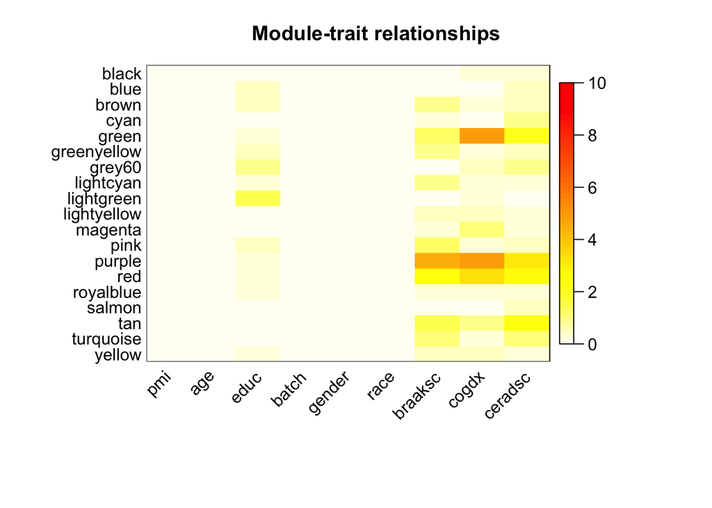

As we expected, there is no module’s eigengene correlated with those biological covariates we corrected. However, it is of interest that purple, red and gree modules correlated with cognitive decline, a manually assessed score per sample that was not used in creating the network. If we check whether these modules are enriched for any cell type, the answer is now. Do it by yourself. But what is the functional annotation for these modules?

```r
e = read.csv("results/netMyRosMap.4.it.20.rds_gprof.csv",stringsAsFactors=F)
sort(table(e$query.number),decreasing=T)
```

```
##
##   turquoise       black   royalblue         red       green      salmon
##         465         436         386         343         207         193
##        cyan        pink  lightgreen        blue     magenta lightyellow
##         173         150         145         141         111         109
##      purple       brown      grey60         tan greenyellow   lightcyan
##         107          98          46          43          39          34
##      yellow
##          11
```

```r
green = e[e$query.number == "green" & e$domain == "keg" ,]
green[order(green$p.value),c("term.name","domain","p.value"),]
```

```
##                              term.name domain  p.value
## 3218              Renal cell carcinoma    keg 2.15e-05
## 3224          Chronic myeloid leukemia    keg 5.99e-04
## 3227        TGF-beta signaling pathway    keg 1.17e-03
## 3221                    Focal adhesion    keg 2.46e-03
## 3225           Proteoglycans in cancer    keg 3.29e-03
## 3226    Neurotrophin signaling pathway    keg 4.84e-03
## 3223 Thyroid hormone signaling pathway    keg 1.90e-02
## 3219                Pathways in cancer    keg 3.27e-02
## 3220                        Cell cycle    keg 3.28e-02
## 3222            ErbB signaling pathway    keg 4.96e-02
```

```r
green = e[e$query.number == "green" & e$domain == "BP" ,]
green[order(green$p.value),c("term.name","domain","p.value"),]
```

```
##                                                                    term.name
## 3072                           regulation of macromolecule metabolic process
## 3092                                     regulation of RNA metabolic process
## 3062                                                RNA biosynthetic process
## 3065                                            transcription, DNA-templated
## 3082                       regulation of nitrogen compound metabolic process
## 3063                                    nucleic acid-templated transcription
## 3095                              regulation of transcription, DNA-templated
## 3094                      regulation of nucleic acid-templated transcription
## 3093                                  regulation of RNA biosynthetic process
## 3091          regulation of nucleobase-containing compound metabolic process
## 3076                                 regulation of primary metabolic process
## 3071                                         regulation of metabolic process
## 3050                                cellular macromolecule metabolic process
## 3090               regulation of cellular macromolecule biosynthetic process
```

[output cut: 235 more lines]

```r
green = e[e$query.number == "green" & e$domain == "CC" ,]
green[order(green$p.value),c("term.name","domain","p.value"),]
```

```
##                                           term.name domain  p.value
## 3169                                        nucleus     CC 4.00e-12
## 3178                                    nucleoplasm     CC 6.17e-11
## 3160                             intracellular part     CC 7.02e-11
## 3174                                   nuclear part     CC 1.54e-10
## 3175                                  nuclear lumen     CC 5.20e-10
## 3159                                  intracellular     CC 8.59e-10
## 3165                        intracellular organelle     CC 4.03e-07
## 3162                                      organelle     CC 8.70e-07
## 3168       intracellular membrane-bounded organelle     CC 9.79e-06
## 3164                     membrane-bounded organelle     CC 1.57e-05
## 3156                        membrane-enclosed lumen     CC 1.61e-05
## 3171                                organelle lumen     CC 1.61e-05
## 3172                  intracellular organelle lumen     CC 1.61e-05
## 3163                 non-membrane-bounded organelle     CC 2.86e-05
## 3166   intracellular non-membrane-bounded organelle     CC 2.86e-05
## 3167                                     chromosome     CC 3.90e-05
## 3179                               chromosomal part     CC 5.56e-05
## 3155                                        cytosol     CC 2.28e-04
## 3173                   intracellular organelle part     CC 4.86e-04
## 3180                                      chromatin     CC 5.89e-04
## 3181                         macromolecular complex     CC 8.57e-04
## 3182              transcriptional repressor complex     CC 2.29e-03
## 3170                                 organelle part     CC 2.60e-03
## 3161                   transcription factor complex     CC 5.77e-03
## 3177 RNA polymerase II transcription factor complex     CC 5.91e-03
## 3158                                      cell part     CC 9.40e-03
## 3157                                           cell     CC 1.37e-02
## 3176           nuclear transcription factor complex     CC 4.24e-02
```

So for green, if we focus on KEGG, there are a number of signals that are related with mainly disease/cancer related pathways. Is this suggesting that cognitive decline is related in some way with cancer of some subtypes of it? By looking at BP and CC, the genes implied are those implied in transcription from DNA to mRNA.

What is the purple module saying to us in relation to cognitive decline?

```r
purple = e[e$query.number == "purple" & e$domain == "keg" ,]
purple[order(purple$p.value),c("term.name","domain","p.value"),]
```

```
##                   term.name domain p.value
## 3025       HTLV-I infection    keg  0.0183
## 3027   Renal cell carcinoma    keg  0.0282
## 3028     Pathways in cancer    keg  0.0324
## 3026 mTOR signaling pathway    keg  0.0342
```

```r
purple = e[e$query.number == "purple" & e$domain == "BP" ,]
purple[order(purple$p.value),c("term.name","domain","p.value"),]
```

```
##                                                                    term.name
## 2963                           transcription from RNA polymerase II promoter
## 2961                                    nucleic acid-templated transcription
## 2960                                                RNA biosynthetic process
## 2962                                            transcription, DNA-templated
## 2958                                                   RNA metabolic process
## 2974                      regulation of nucleic acid-templated transcription
## 2959                     nucleobase-containing compound biosynthetic process
## 2973                                  regulation of RNA biosynthetic process
## 2971                                     regulation of RNA metabolic process
## 2951                                        heterocycle biosynthetic process
## 2984                     negative regulation of transcription, DNA-templated
## 2975                              regulation of transcription, DNA-templated
## 2985    negative regulation of transcription from RNA polymerase II promoter
## 2983             negative regulation of nucleic acid-templated transcription
```

[output cut: 149 more lines]

```r
purple = e[e$query.number == "purple" & e$domain == "CC" ,]
purple[order(purple$p.value),c("term.name","domain","p.value"),]
```

```
##                                     term.name domain  p.value
## 3012 intracellular membrane-bounded organelle     CC 5.99e-09
## 3010                  intracellular organelle     CC 1.86e-08
## 3008                            intracellular     CC 2.52e-08
## 3009                       intracellular part     CC 5.41e-08
## 3013                                  nucleus     CC 8.25e-08
## 3005                                organelle     CC 1.17e-05
## 3016                              nucleoplasm     CC 1.34e-05
## 3014                             nuclear part     CC 8.29e-05
## 3015                            nuclear lumen     CC 4.65e-04
## 3006               membrane-bounded organelle     CC 4.92e-04
## 3017                         nucleoplasm part     CC 8.20e-04
## 3011             intracellular organelle part     CC 4.47e-02
## 3007                           organelle part     CC 4.80e-02
```

Not surprisingly, it is telling us the same story.

# Exercises

- Can you describe what is inside the red module?
- How can we get to know more about genes within a module? Try the User_terms file. Try also Topp Gene tool
- What are the most relevant (top 5) genes with these three modules? What can we say about them?

Help with the last exercise, try

```r
coexp.getModuleMostRelevantGenes(which.one="new",
                                 tissue="results/netMyRosMap.4.it.20.rds",
                                 module="red",
                                 expr.data.file="examples/rosmap_residuals.rds")
```